# Effects of Natural Disasters in USA From NOAA Storm Database, both Health and Economic Effects are Explored

SAI

July 22, 2018

# Effects of Natural Disasters in USA From NOAA Storm Database, both Health and Economic Effects are Explored

## Synopsis

In united states we have large varieties of Natural Disasters that affect and cause damage both from economic point and health point. SO we are trying to analyze which type of natural disasters are causing more affects so that we can take necessary actions.

The data has been taken from the NOAA database and analysed to give the following two solutions:

1. Across the United States, which types of events (as indicated in the EVTYPE variable) are most harmful with respect to population health?
2. Across the United States, which types of events have the greatest economic consequences?

dplyr package is used to process the data and to produce the plots that can give us the perfect solutions to the above questions

## Data Processing

STEP1: Iputting the data in to RStudio and getting the feel of data including the dimensions

```r
setwd("C:/Users/pavansai/Desktop/DS")
Input_data <- read.csv(bzfile("repdata%2Fdata%2FStormData.csv.bz2"),sep = ",", header = TRUE)
head(Input_data)
```

```
##   STATE__           BGN_DATE BGN_TIME TIME_ZONE COUNTY COUNTYNAME STATE
## 1       1  4/18/1950 0:00:00     0130       CST     97     MOBILE    AL
## 2       1  4/18/1950 0:00:00     0145       CST      3    BALDWIN    AL
## 3       1  2/20/1951 0:00:00     1600       CST     57    FAYETTE    AL
## 4       1   6/8/1951 0:00:00     0900       CST     89    MADISON    AL
## 5       1 11/15/1951 0:00:00     1500       CST     43    CULLMAN    AL
## 6       1 11/15/1951 0:00:00     2000       CST     77 LAUDERDALE    AL
##    EVTYPE BGN_RANGE BGN_AZI BGN_LOCATI END_DATE END_TIME COUNTY_END
## 1 TORNADO         0                                               0
## 2 TORNADO         0                                               0
## 3 TORNADO         0                                               0
## 4 TORNADO         0                                               0
## 5 TORNADO         0                                               0
## 6 TORNADO         0                                               0
##   COUNTYENDN END_RANGE END_AZI END_LOCATI LENGTH WIDTH F MAG FATALITIES
```

[output cut: 20 more lines]

```r
dim(Input_data)
```

```
## [1] 902297     37
```

```r
names(Input_data)
```

```
##  [1] "STATE__"    "BGN_DATE"   "BGN_TIME"   "TIME_ZONE"  "COUNTY"
##  [6] "COUNTYNAME" "STATE"      "EVTYPE"     "BGN_RANGE"  "BGN_AZI"
## [11] "BGN_LOCATI" "END_DATE"   "END_TIME"   "COUNTY_END" "COUNTYENDN"
## [16] "END_RANGE"  "END_AZI"    "END_LOCATI" "LENGTH"     "WIDTH"
## [21] "F"          "MAG"        "FATALITIES" "INJURIES"   "PROPDMG"
## [26] "PROPDMGEXP" "CROPDMG"    "CROPDMGEXP" "WFO"        "STATEOFFIC"
## [31] "ZONENAMES"  "LATITUDE"   "LONGITUDE"  "LATITUDE_E" "LONGITUDE_"
## [36] "REMARKS"    "REFNUM"
```

```r
library(dplyr)
```

## Gathering The required data using the dplyr package

The dplyr package is used to gather the data regarding the natural disasters that are cauisng problems both economically and health point of view

```r
Total_combineddata <- Input_data %>% select(EVTYPE, FATALITIES, INJURIES)
Fatalities_data <- Input_data %>% select(EVTYPE, FATALITIES)
Injuries_data   <- Input_data %>% select(EVTYPE, INJURIES)
```

## Plotting the Fatalities and Injuries

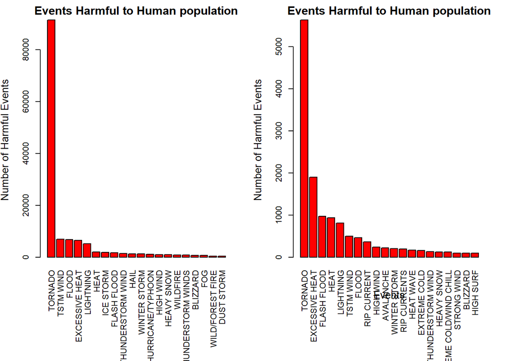

```r
par(mfrow = c(1, 2), mar = c(10, 4, 2, 2), las = 3, cex = 0.7, cex.main = 1.4, cex.lab = 1.2)
Fatalities_data_SUM <- Fatalities_data %>% group_by(EVTYPE) %>% summarize(total_fatal = sum(FATALITIES))
fatalities <- Fatalities_data_SUM[order(-Fatalities_data_SUM$total_fatal), ][1:20,]
INJURIES_data_SUM <- Injuries_data %>% group_by(EVTYPE) %>% summarize(total_Injuries = sum(INJURIES))
Injuries <- INJURIES_data_SUM[order(-INJURIES_data_SUM$total_Injuries), ][1:20,]
barplot(Injuries$total_Injuries, names.arg = Injuries$EVTYPE  , col = 'red', main = "Events Harmful to Human population", ylab = "Number of Harmful Events")
barplot(fatalities$total_fatal, names.arg = fatalities$EVTYPE  , col = 'red', main = "Events Harmful to Human population", xlab = "Events", ylab = "Number of Harmful Events")
```

## Plotting the combined data

```r
Combined_data_SUM <- Total_combineddata %>% group_by(EVTYPE) %>% summarize(total_Events = sum(INJURIES) + sum(FATALITIES))
```

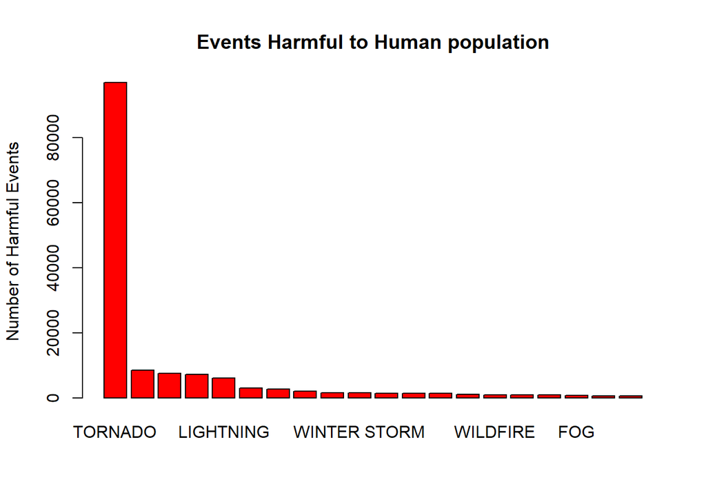

```r
Combined_data <- Combined_data_SUM[order(-Combined_data_SUM$total_Events), ][1:20,]
barplot(Combined_data$total_Events, names.arg = Combined_data$EVTYPE  , col = 'red', main = "Events Harmful to Human population", ylab = "Number of Harmful Events")
```

From the above graph Torandos are the highest damaging causing natural EVents and followed by Excessive Heating. It is similar in the othe individual graphs also.

## Selecting the data for the events of greatest economic consequences

Here i am selecting the EVents that are causing the greatest damage in terms of Economy point of view

```r
Input_data$PROPDMGNUM = 0
Input_data[Input_data$PROPDMGEXP == "H", ]$PROPDMGNUM = Input_data[Input_data$PROPDMGEXP == "H", ]$PROPDMG * 10^2
Input_data[Input_data$PROPDMGEXP == "K", ]$PROPDMGNUM = Input_data[Input_data$PROPDMGEXP == "K", ]$PROPDMG * 10^3
Input_data[Input_data$PROPDMGEXP == "M", ]$PROPDMGNUM = Input_data[Input_data$PROPDMGEXP == "M", ]$PROPDMG * 10^6
Input_data[Input_data$PROPDMGEXP == "B", ]$PROPDMGNUM = Input_data[Input_data$PROPDMGEXP == "B", ]$PROPDMG * 10^9

Input_data$CROPDMGNUM = 0
Input_data[Input_data$CROPDMGEXP == "H", ]$CROPDMGNUM = Input_data[Input_data$CROPDMGEXP == "H", ]$CROPDMG * 10^2
Input_data[Input_data$CROPDMGEXP == "K", ]$CROPDMGNUM = Input_data[Input_data$CROPDMGEXP == "K", ]$CROPDMG * 10^3
Input_data[Input_data$CROPDMGEXP == "M", ]$CROPDMGNUM = Input_data[Input_data$CROPDMGEXP == "M", ]$CROPDMG * 10^6
Input_data[Input_data$CROPDMGEXP == "B", ]$CROPDMGNUM = Input_data[Input_data$CROPDMGEXP == "B", ]$CROPDMG * 10^9

Total_Economic_combineddata <- Input_data %>% select(EVTYPE,PROPDMGNUM,CROPDMGNUM)
```

## Plotting the events that are causing the maximum Economic Damage

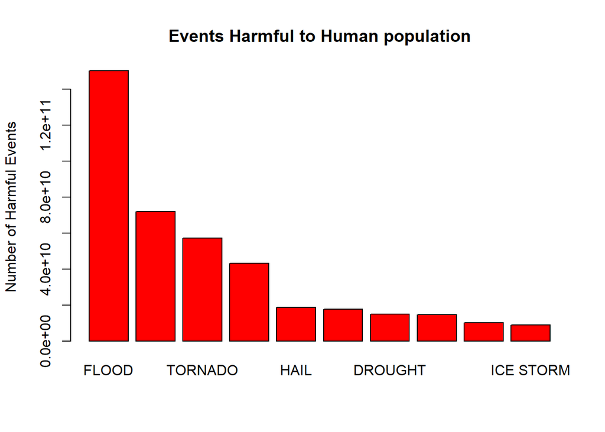

```r
total_Combined_data_SUM <- Total_Economic_combineddata %>% group_by(EVTYPE) %>% summarize(total_Events = sum(PROPDMGNUM) + sum(CROPDMGNUM))
Economic_disasters_Combined_data <- total_Combined_data_SUM[order(-total_Combined_data_SUM$total_Events), ][1:10,]
barplot(Economic_disasters_Combined_data$total_Events, names.arg = Economic_disasters_Combined_data$EVTYPE  , col = 'red', main = "Events Harmful to Human population", ylab = "Number of Harmful Events")
```

From the above graph we can see that floods are causing the Highest amount of damage followed by Hurricanes, Tornadoes, Stormsurges

## Results

So from the above graphs we can conclude that the from the Health point of view Tornados are causing the highest damges where as from the economic point of view the highest damage is caused by the floods.

Therefore respective authorities should take care of this inorder to prevent future damages.